# R Notebook

# EPA Water Quality Analysis

# Data Cleaning

This section outlines the process needed for cleaning data taken from EPA.gov.

There are two datasets:

The first dataset contains data pertaining to water quality samples at a given site.

The second data set contains information relating to that site such as latitude and longitude data.

We will need to combine these datasets.

In order to join any two datasets there must be a common field(s).

This case it is the `site_id`.

The below code chunk:

1. Load the `tidyverse`
2. Creates variables that store the URL of the csv files
3. Read the datasets and standardizes the column names using th `clean_names()` function from janitor.

```r
library(tidyverse)
# identify water quality csv
water_url <- "https://www.epa.gov/sites/production/files/2014-10/nla2007_chemical_conditionestimates_20091123.csv"

# site info csv (w lat lon data)
site_url <- "https://www.epa.gov/sites/production/files/2014-01/nla2007_sampledlakeinformation_20091113.csv"

# read sites
sites <- read_csv(site_url) %>%
  janitor::clean_names()
# read water
water_q <- read_csv(water_url) %>%
  janitor::clean_names()
```

Now that we have these datasets we will need to join them together.

In this case we will join three tables together:

- Water Quality dataset
- Site location data
- State abbreviation and region data

We first take only a few columns of interest from the `sites` dataset.

This is then piped ( %>% ) into an `inner_join()` (all columns from x and y where there is a match between x and y).

The resultant table is then passed forward into a `left_join()` (all columns from x and y where returning all rows from x). In this join the y table is explicitly created from the built in R objects `state.abb` and `state.region`.

Then, a `select()` statement is used to change some column names, select only the columns of interest. Finally, the tibble is written to the `data` directory (run `mkdir("data")`) if the directory does not exist.

```r
# join together
# join together
clean <- select(sites, lon_dd, lat_dd, lakename, site_id, state_name, st) %>%
  inner_join(water_q, by = "site_id") %>%
  # join a table that has region info
  left_join(
    tibble(st = state.abb,
           region = state.region), by = c("st.y" = "st")
  ) %>%
  # select only data of interest
  select(contains("_cond"), ptl, ntl, chla, st = st.x, region,
         lon_dd = lon_dd.x, lat_dd = lat_dd.x, lakename)


#write_csv(clean, "data/water_quality.csv")
```

# Exploratory analysis

```r
water <- read_csv("~/EPA-2019-Shiny-Rmd-Research-Workshop/epa-water-quality-master/epa-water-quality-master/data/water_quality.csv")
```

```r
glimpse(water)
```

```
Observations: 1,442
Variables: 14
$ ptl_cond      <chr> "1:LEAST DISTURBED", "2:INTERMEDI…
$ ntl_cond      <chr> "1:LEAST DISTURBED", "2:INTERMEDI…
$ chla_cond     <chr> "1:LEAST DISTURBED", "1:LEAST DIS…
$ turb_cond     <chr> "1:LEAST DISTURBED", "1:LEAST DIS…
$ anc_cond      <chr> "1:LEAST DISTURBED", "1:LEAST DIS…
$ salinity_cond <chr> "1:LEAST DISTURBED", "1:LEAST DIS…
$ ptl           <dbl> 6, 36, 22, 36, 22, 43, 50, 43, 50…
$ ntl           <dbl> 151, 695, 469, 695, 469, 738, 843…
$ chla          <dbl> 0.24, 3.84, 20.88, 3.84, 20.88, 1…
$ st            <chr> "MT", "SC", "SC", "SC", "SC", "TX…
$ region        <chr> "West", "South", "South", "South"…
$ lon_dd        <dbl> -114.02184, -79.98379, -79.98379,…
$ lat_dd        <dbl> 48.97903, 33.03606, 33.03606, 33.…
$ lakename      <chr> "Lake Wurdeman", "Crane Pond", "C…
```

Use ggplot2 to explore the relationship between numeric variables.

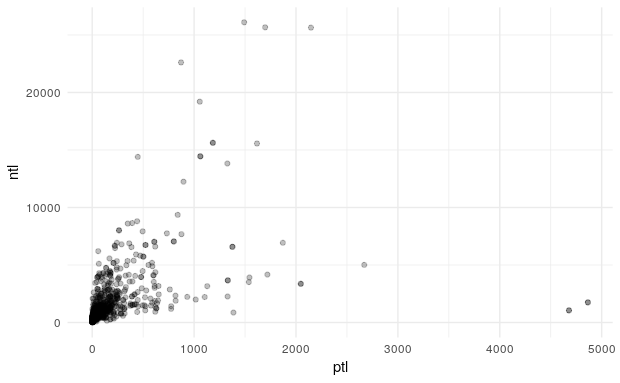

```r
water %>%
  ggplot(aes(ptl, ntl)) +
  geom_point(alpha = .25) +
  theme_minimal()
```

Notice the fanning nature of the chart,this alludes to a log normal distribution. Apply log transformations on both axes via `scale_x/y_log10()`.

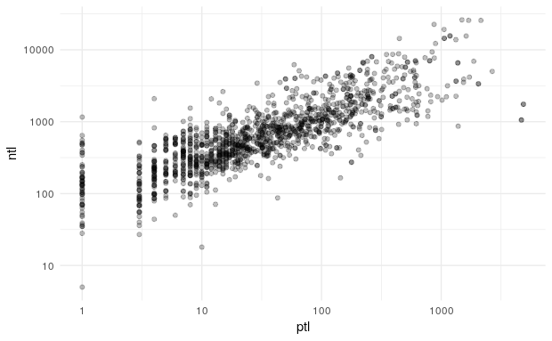

```r
water %>%
  ggplot(aes(ptl, ntl)) +
  geom_point(alpha = .25) +
  theme_minimal() +
  scale_x_log10() +
  scale_y_log10()
```

Stop Here…

Wonderful! Now there is a clear linear trend. Try applying a linear regression to the data using `geom_smooth()`

```r
water %>%
  ggplot(aes(ptl, ntl)) +
  geom_point(alpha = .25) +
  theme_minimal() +
  scale_x_log10() +
  scale_y_log10() +
  geom_smooth(method = "lm")
```

[output not shown]

This is great! What are the values of our coefficient though? Fit a model.

```r
mod <- lm(log10(ntl) ~ log10(ptl), data = water)

summary(mod)
```

[output not shown]

How does this change for a single region? We can filter the data.

```r
mod_west <- lm(log10(ntl) ~ log10(ptl), data = filter(water, region == "West"))
summary(mod_west)
```

[output not shown]

There is some variation in this. What about all other regions? We can use `purrr` to create multiple models.

```r
region_mods <- water %>%
  nest(-region) %>%
  mutate(mod = map(.x = data, .f = ~lm(log10(.x$ntl) ~ log10(.x$ptl))),
         # create a nested tibble for model coefs
         results = map(mod, broom::tidy),
         # create nested tibble for model metrics
         summary = map(mod, broom::glance))
```

We can unnest different tibbles. For the coefficients unnest the `results`.

```r
unnest(region_mods, results)
```

[output not shown]

## Mapping data

To map data we can take advantage of `leaflet` and `sf`. We will create a simple feature object which has a column containing geometry information. We use `st_as_sf()` to convert to a spatial object. Use the argument `coords` to tell which columns correspond to latitude and logitude.

```r
library(sf)
```

```r
water_sf <- water %>%
  st_as_sf(coords = c("lon_dd", "lat_dd"))

class(water_sf)
```

[output not shown]

You can see now that this is still a data frame but is also of class `sf`.

We can use this sf object to plot some markers with leaflet.

```r
library(leaflet)

leaflet(water_sf) %>%
        addTiles() %>%
        addMarkers()
```

This creates markers for each measurement, but it would be nice to have a popup message associated with each one. We can create a message with `mutate()` and `glue()`. Note that the `<br>` tag is an html tag that creates a new line.

```r
water_sf %>%
  mutate(msg = glue::glue({
    "Name: {lakename}<br>
    Chlorphylla: {chla}<br>
    Nitrogen: {ntl}<br>
    Phosphorus: {ptl}<br>"})) %>%
  leaflet() %>%
  addTiles() %>%
  addMarkers(popup = ~msg)
```